# Impact of Immigration on Extreme Right Vote

## Random Forest Model

```r
library(randomForest)
rf.er = randomForest(rexfactor ~ male + age1 + age2 + age4 + mye1 + mye2 + farmerown + worker + retired + unemployed + zlrs + euschlecht + zsatisdmo + disp + lfed1 + migration + sur + migration:sur + replacementrate + rmax + salienzmean + rvar + country, data=new.data2, subset = train, importance =TRUE)
outcome.rf = predict(rf.er ,newdata=new.data2[-train,])
table(outcome.rf, rexfactor[-train])
```

```
##
## outcome.rf     0     1
##          0 16409   697
##          1    38    65
```

```r
mean(outcome.rf == rexfactor[-train])
```

```
## [1] 0.9572898
```

```r
importance(rf.er)
```

```
##                         0           1 MeanDecreaseAccuracy
## male            -2.756848  9.09585431             1.286159
## age1             4.147540  3.78728220             5.340983
## age2             2.499988  1.99402744             3.085317
## age4             4.643957  0.05601207             4.505649
## mye1             5.364244  0.93438785             5.428808
## mye2            22.588708 -4.12714307            21.277849
## farmerown        1.829074 -0.50764823             1.483759
## worker           5.788381 12.35239701            10.073877
## retired          9.401220  0.12278501             9.291759
## unemployed      13.616192  7.40852881            15.464177
## zlrs            56.959797 79.72957122            75.990534
## euschlecht      22.240344 13.38243941            25.211614
## zsatisdmo       40.323963 18.83404216            44.378053
## disp            13.704767 12.85368404            15.293726
## lfed1           13.543515  6.89327866            14.164895
## migration       17.366454  5.22526075            18.345611
## sur             16.337275  6.36298288            17.679322
## replacementrate 19.563174 10.81355312            21.223532
## rmax            15.887635  4.35746714            16.644409
## salienzmean     18.882758  4.22233283            20.422028
## rvar            16.687787  6.71654161            18.980777
## country         23.294724 11.77508393            24.549343
##                 MeanDecreaseGini
## male                    37.52798
## age1                    35.83070
## age2                    35.38776
## age4                    18.61981
## mye1                    37.89163
## mye2                    31.41898
## farmerown               21.38115
## worker                  34.79048
## retired                 24.06627
## unemployed              21.44087
## zlrs                   209.99059
## euschlecht              35.72724
## zsatisdmo               84.89876
## disp                    15.52997
## lfed1                   10.29183
## migration               27.72242
## sur                     32.35950
## replacementrate         31.36175
## rmax                    52.56076
## salienzmean             57.13456
## rvar                    54.59679
## country                 22.83104
```

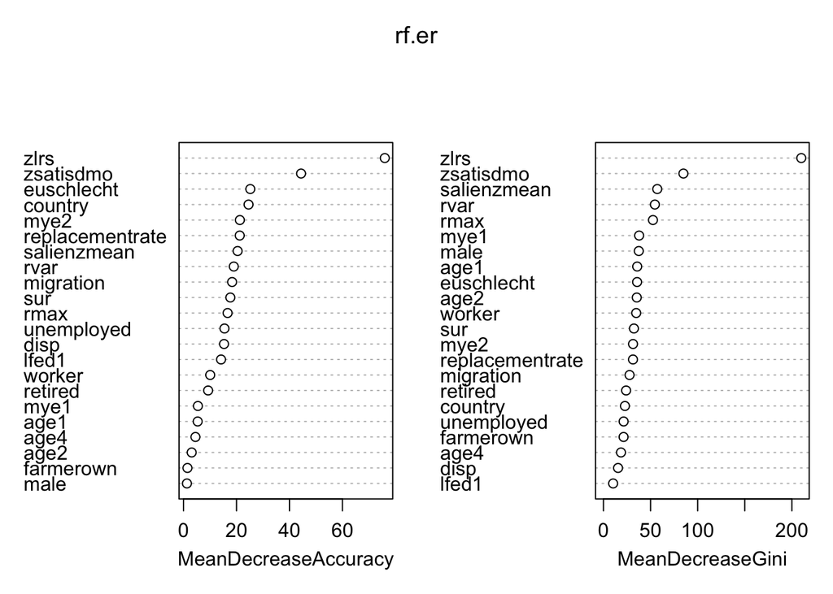

```r
varImpPlot(rf.er)
```

# Part 2: Effect of Higher Education

After building regression models in which we saw that receiving university education lowers the logit score, we want to test if there is an actual effect of atending university on likelihood of voting for the extreme right. Towards this goal we will employ genetic matching. University education is the treatment variable and other personal as well as demographic data will be balanced on to estimate a treatment effect.

```r
library(Matching)
set.seed(2)
new.data2 <- na.omit(new.data)
new.data3 <- new.data2
Y <- new.data3$rexvote
Tr <- new.data3$mye2
male <- new.data3$male == "ja"

## Eliminate Variables that covary with university education such as: low education, left/right, dissatisfied with EU or Democracy

X <- cbind(male, new.data3$age1, new.data3$age2, new.data3$age4, new.data3$farmerown, new.data3$worker, new.data3$retired, new.data3$unemployed, new.data3$disp, new.data3$lfed1, new.data3$migration, new.data3$sur, new.data3$replacementrate, new.data3$rmax, new.data3$salienzmean, new.data3$at, new.data3$be, new.data3$deo, new.data3$dew, new.data3$dk, new.data3$es, new.data3$fi, new.data3$fr, new.data3$gr, new.data3$it, new.data3$nl, new.data3$no, new.data3$pt, new.data3$se)
colnames(X) <- c("male","age1","age2","age4","farmerown","worker","retired","unemployed","disp","lfed1","migration","sur","replacementrate","rmax","salienzmean","AT", "BE","DE-E","DE-W","DK","ES","FI","FR","GR","IT","NL","NO","PT","SE")

BalanceMat <- X

## Skipping GenMatch in knitted HTMl file, as it takes over an hour to complete and determines the ideal weights to be 1 for each variable under this caliper (we can do exact matching)
##gmout <- GenMatch(Tr=Tr, X=X, BalanceMat=BalanceMat, estimand="ATT", pop.size = 20, max.generations = 15, caliper = c(1,1,1,1,1,1,1,1,1,.5,.1,.1,.3,.01,.01,1,1,1,1,1,1,1,1,1,1,1,1,1,1), wait.generations = 3)

match <- Match(Y=Y, Tr=Tr, X=X, caliper = c(1,1,1,1,1,1,1,1,1,.5,.1,.1,.3,.01,.01,1,1,1,1,1,1,1,1,1,1,1,1,1,1))
summary(match)
```

```
##
## Estimate...  -0.02022
## AI SE......  0.0030685
## T-stat.....  -6.5895
## p.val......  4.4118e-11
##
## Original number of observations..............  34418
## Original number of treated obs...............  12163
## Matched number of observations...............  12056
## Matched number of observations  (unweighted).  218626
##
## Caliper (SDs)........................................   1 1 1 1 1 1 1 1 1 0.5 0.1 0.1 0.3 0.01 0.01 1 1 1 1 1 1 1 1 1 1 1 1 1 1
## Number of obs dropped by 'exact' or 'caliper'  107
```

```r
mb <- MatchBalance(Tr ~ X, match.out=match, nboots=100)
```

```
##
## ***** (V1) Xmale *****
##                        Before Matching        After Matching
## mean treatment........    0.41659            0.41755
## mean control..........    0.49814            0.41755
## std mean diff.........     -16.54                  0
##
## mean raw eQQ diff.....   0.081559                  0
## med  raw eQQ diff.....          0                  0
## max  raw eQQ diff.....          1                  0
##
## mean eCDF diff........   0.040772                  0
## med  eCDF diff........   0.040772                  0
## max  eCDF diff........   0.081544                  0
##
## var ratio (Tr/Co).....    0.97222                  1
## T-test p-value........ < 2.22e-16                  1
##
##
## ***** (V2) Xage1 *****
##                        Before Matching        After Matching
## mean treatment........    0.31645            0.31768
## mean control..........    0.22584            0.31768
## std mean diff.........     19.482                  0
##
## mean raw eQQ diff.....   0.090603                  0
## med  raw eQQ diff.....          0                  0
## max  raw eQQ diff.....          1                  0
##
## mean eCDF diff........   0.045307                  0
## med  eCDF diff........   0.045307                  0
## max  eCDF diff........   0.090615                  0
##
## var ratio (Tr/Co).....     1.2373                  1
## T-test p-value........ < 2.22e-16                  1
##
##
## ***** (V3) Xage2 *****
##                        Before Matching        After Matching
## mean treatment........    0.36036            0.36131
```

[output cut: 493 more lines]

```
## med  raw eQQ diff.....          0                  0
## max  raw eQQ diff.....          0                  0
##
## mean eCDF diff........          0                  0
## med  eCDF diff........          0                  0
## max  eCDF diff........          0                  0
##
## var ratio (Tr/Co).....        NaN                NaN
## T-test p-value........          1                  1
##
##
## Before Matching Minimum p.value: < 2.22e-16
## Variable Name(s): Xmale Xage1 Xage2 Xage4 Xfarmerown Xworker Xretired Xdisp Xlfed1 Xmigration Xsur Xreplacementrate Xrmax Xsalienzmean XDE-W XDK XES XIT XNO XPT  Number(s): 1 2 3 4 5 6 7 9 10 11 12 13 14 15 19 20 21 25 27 28
##
## After Matching Minimum p.value: 1
```

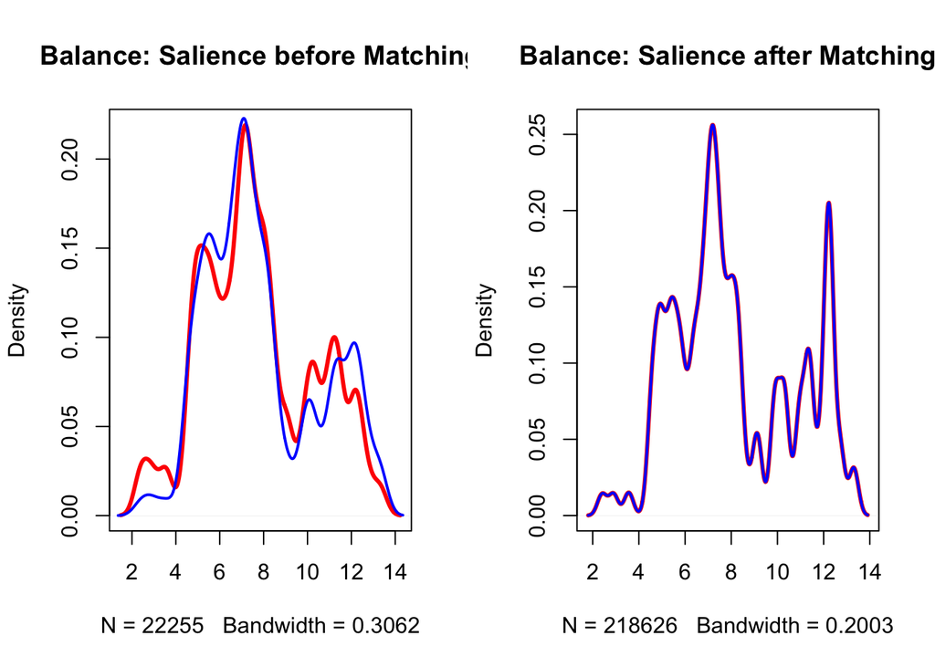

```r
par(mfrow = c(1,2))

plot(density(new.data3$salienzmean[Tr==0]), lwd = 3, col = "red", main = "Balance: Salience before Matching")
lines(density(new.data3$salienzmean[Tr==1]), lwd = 2, col = "blue")

plot(density(new.data3$salienzmean[match$index.control]), lwd = 3, col = "red", main = "Balance: Salience after Matching")
lines(density(new.data3$salienzmean[match$index.treated]), lwd = 2, col = "blue")
```

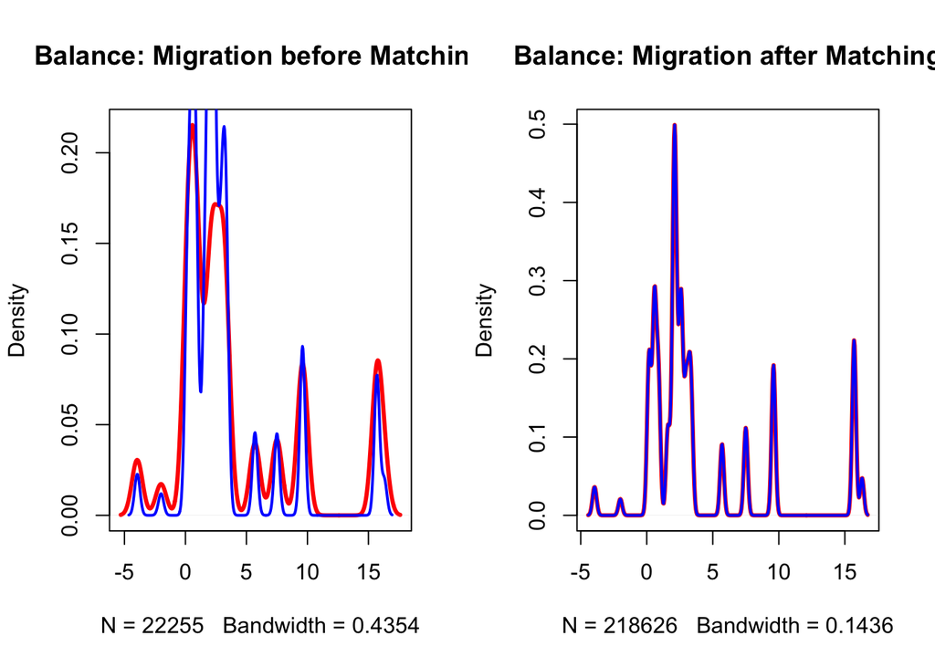

```r
plot(density(new.data3$migration[Tr==0]), lwd = 3, col = "red", main = "Balance: Migration before Matching")
lines(density(new.data3$migration[Tr==1]), lwd = 2, col = "blue")

plot(density(new.data3$migration[match$index.control]), lwd = 3, col = "red", main = "Balance: Migration after Matching")
lines(density(new.data3$migration[match$index.treated]), lwd = 2, col = "blue")
```

```r
# Sensitivity Analysis on these results
require(rbounds)
psens(match, Gamma = 2, GammaInc = 0.05)
```

```
##
##  Rosenbaum Sensitivity Test for Wilcoxon Signed Rank P-Value
##
## Unconfounded estimate ....  0
##
##  Gamma Lower bound Upper bound
##   1.00           0      0.0000
##   1.05           0      0.0000
##   1.10           0      0.0000
##   1.15           0      0.0000
##   1.20           0      0.0000
##   1.25           0      0.0000
##   1.30           0      0.0000
##   1.35           0      0.0000
##   1.40           0      0.0000
##   1.45           0      0.0000
##   1.50           0      0.0029
##   1.55           0      0.2554
##   1.60           0      0.9159
##   1.65           0      0.9996
##   1.70           0      1.0000
##   1.75           0      1.0000
##   1.80           0      1.0000
##   1.85           0      1.0000
##   1.90           0      1.0000
##   1.95           0      1.0000
##   2.00           0      1.0000
##
##  Note: Gamma is Odds of Differential Assignment To
##  Treatment Due to Unobserved Factors
##
```